# Section 3.1 Inference: Confidence Intervals

Last updated Thursday, October 08, 2026 @ 05:40 PM

## Before We Begin…

These slides are meant to accompany the text [*Introduction to Statistical Investigations, 2nd Edition*](http://www.isi-stats.com/isi/index2nd.html) — Section 3.1 Statistical Inference: Confidence Intervals.

*This content does not replace reading the relevant textbook section.* It is for class presentation, review, and reference.

## Recall: Spiral Approach & Four Pillars

- We addressed strength of evidence (significance) in Chapter 1. ✔ *Good job!*
- We addressed breadth of results (generalization) in Chapter 2. ✔ *Great work!*
- **We will discover the *size* of an effect (estimation) in Chapter 3.**
- Chapter 4 will introduce the concept of causation, the last of the four pillars.

## Learning Goals for Chapter 3

Chapter 3 focuses on *estimation*. We can estimate how large an effect is using an *interval* of statistically likely or plausible values.

- Construct and interpret a confidence interval for a single population proportion using the range of plausible values technique. [Section 3.1]
- Construct and interpret a confidence interval for a single population proportion using both 2SD and theory-based methods. [Section 3.2]
- Construct and interpret a confidence interval for a single population mean using both 2SD and theory-based methods. [Section 3.3]
- Identify how factors (confidence level, sample size, SD) affect the width of the confidence interval. [Section 3.4]

## Learning Goals for Section 3.1

In Chapter 3, you will learn two different ways to find confidence intervals, based on methods from Chapters 1 and 2. The first is an interval of plausible values — those values of the parameter that are *not* rejected using a two-sided test of significance.

- Complete multiple two-sided tests of significance, using the same value for the sample proportion but changing the value under the null hypothesis, and obtain an interval of plausible values for the population parameter.
- Interpret an interval of plausible values as estimating the population parameter and as a confidence interval.
- Based on the results of a test of significance, infer whether or not a value is in the confidence interval and vice versa.

## Section 3.1 New Vocabulary

- confidence interval
- confidence level
- estimate / estimation
- plausible value(s)
- significance level

This chapter builds on Chapters 1 and 2, so you also will want to be sure that you have solidified vocabulary from those chapters, including (but not limited to) terms such as…

- null hypothesis and parameter
- sampling distribution
- test of significance

**confidence interval :** An inference tool we use to estimate the value of a parameter such as \(\pi\), with an associated measure of uncertainty due to randomness in the sampling method.

**confidence level :** A statement of reliability we make about the confidence interval method.

**estimation :** In the context of confidence intervals, it describes how large an effect is, expressed as a range of values for the parameter we are interested in.

**plausible value :** A parameter value that we test under the null hypothesis and where we *do not* find strong evidence against the null (\(H_0\) is not rejected)—based on the observed data.

**significance level :** A value used as a criterion for deciding how small a *p*-value in a test of significance needs to be to provide convincing evidence against the null hypothesis.

## Method of Plausible Values

First, we test many different values of \(\pi\) in the null hypothesis.

\[H_0: \pi = \text{value being tested}\]

\[H_a: \pi \ne \text{value being tested}\]

Calculate a two-sided *p*-value using the observed data, like we learned to do in Section 1.4.

Reject \(H_0\) *or* fail to reject \(H_0\) using the *p*-value and the chosen level of significance (usually \(\alpha = 0.05\)). If you fail to reject \(H_0\), the tested \(\pi\) is a *plausible value* and part of the interval.

The confidence interval boundaries are the smallest and largest plausible values, written as (*lower boundary*, *upper boundary*).

## What Does 95% Confidence Mean?

Let us start with what it does *not* mean. It does not mean that there is a 95% chance that the actual value of the parameter is in the 95% confidence interval. Why not?

The parameter value is fixed and the interval is random. If you chose a different sample, you’d get a different interval, but the parameter value would still be the same.

What we mean is that 95% of all samples give an interval that covers the true value. The 95% is the “coverage probability” or “capture rate” of the method we are using.

Picture a game of horseshoes. The parameter is the iron stake in the ground, which does not move. Each toss of a horseshoe is an interval. Our method is a like really good player who can get a horseshoe around the stake 95% of the time.

## Why Can’t We Be Sure?

[figure not shown]

We could have a 100% confidence interval for a \(\pi\) if we said the value was definitely between 0 and 1 — but that would not be useful in most real-world research contexts, would it?

Theory-based confidence intervals for many statistics are based on the Normal distribution. The tails of the bell curve extend to infinity in both directions, so a 100% confidence interval would be infinitely wide, which is also not useful!

## Flashback: Harley the Wonder Doggo

In Section 1.1, we explored the question “Can Dogs Understand Human Cues?” In a particular set of 10 trials, Harley was able to pick the correct cup 9 out of 10 times. We decided that this was statistically significant and \(H_0: \pi = 0.50\) was implausible.

So, if Harley is not purely guessing when the experimenter bows toward the cup, what is his true long-run probability \(\pi\) of picking the correct cup? After the test we just know \(H_a: \pi > 0.5\).

Given that \(\hat{p} = 0.90\), that might be a good estimate (i.e., *best statistical guess*) for the value of \(\pi\). We call that a *point estimate*.

However, this is sample data, and we all know that it has some random variability. Maybe \(\pi\) is slightly different than \(0.90\), like \(0.89\). Could it be even more different, like \(0.80\)? Or \(0.70\)?

We systematically test values for \(\pi\) on either side of \(\pi = 0.90\), until we get \(\pi\) values that are implausible. We will use the [One Proportion](https://www.isi-stats.com/isi2nd/ISIapplets2021.html) applet like the original test, with a two-tailed \(H_a\).

| Value of \(\pi\) tested in \(H_0\) | 0.56 | 0.57 | … | 0.85 | 0.90 | 0.95 | 0.99 | 1.00 |
| --- | --- | --- | --- | --- | --- | --- | --- | --- |
| Two-sided *p*-value | 0.049 | 0.052 | … | 1.000 | 1.000 | 0.404 | 0.096 | NA |
| Reject Ho? | Yes | No | … | No | No | No | No | NA |
| Plausible \(\pi\)? | **NO** | Yes | … | Yes | Yes | Yes | Yes | **NO** |

We know 1 is impossible. That would mean Harley is guaranteed to *always* choose the correct cup. Data show that is false.

We are 95% confident that \(\pi\) is between \(0.57\) and \(0.99\). To get a narrower interval of plausible values, we would need more data.

## Flashback: Bottled Water vs. Tap Water

In Section 1.2, we explored whether or not people prefer bottled water to tap water. The sample proportion of people who chose bottled water in the experiment was \(\hat{p}= 24/27 = 0.89\).

Performing two-tailed significance tests on potential values of \(\pi\) that are less than \(\hat{p} = 0.89\), we get \(0.71\) as a lower boundary.

| Value of \(\pi\) tested in \(H_0\) | 0.70 | 0.71 | 0.72 | 0.73 | 0.74 | 0.75 | … | 0.89 |
| --- | --- | --- | --- | --- | --- | --- | --- | --- |
| Two-sided *p*-value | 0.039 | 0.052 | 0.064 | 0.085 | 0.094 | 0.109 | … | 1.000 |
| Reject Ho? | Yes | No | No | No | No | No | … | No |
| Plausible \(\pi\)? | **NO** | Yes | Yes | Yes | Yes | Yes | … | Yes |

## An Example of Testing

The image below comes from the [One Proportion](https://www.isi-stats.com/isi2nd/ISIapplets2021.html) applet for the test to evaluate \(H_0: \pi = 0.71\). Notice the process settings for \(\pi\) and \(n\), sample statistic \(0.89\), and “Two-sided” *p*-value option.

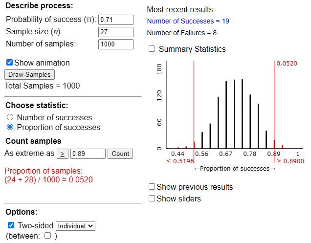

Testing values more than \(0.89\) for the largest plausible \(\pi\) value.

| Value of \(\pi\) tested in \(H_0\) | 0.89 | … | 0.92 | 0.93 | 0.94 | 0.95 | 0.96 | 0.97 |
| --- | --- | --- | --- | --- | --- | --- | --- | --- |
| Two-sided *p*-value | 1.000 | … | 0.484 | 0.429 | 0.207 | 0.136 | 0.084 | 0.047 |
| Reject Ho? | No | … | No | No | No | No | No | Yes |
| Plausible \(\pi\)? | Yes | … | Yes | Yes | Yes | Yes | Yes | **NO** |

We are 95% confident that \(\pi\) is between \(0.71\) and \(0.96\).

The way the bottled versus tap water experiment was done, the probability value for people randomly choosing a cup was \(0.75\). The fact that \(0.75\) is inside our interval means we cannot reject the idea that people have no preference.